# Guess Meaning analysis

marcobarilari

01/23/2020

## Load and reshape the data

Load the data and match the columns, then bind them in one dataframe

```r
path_raw <- '/Users/barilari/Desktop/GuessMeaning_final-data/raw'

raw_allGorilla <- read.table(paste(path_raw, 'raw_allGorilla.tsv', sep = '/'),
                                 header = T,
                                 sep = '\t')

raw_allMatlab <- read.table(paste(path_raw, 'raw_allMatlab.tsv', sep = '/'),
                                header = T,
                                sep = '\t')

allGorilla <- raw_allGorilla %>%
  select(-rotation)

allMatlab <- raw_allMatlab %>%
  select(-subjNb, -expTrialNb, -buttonOrder, -categoryTrialNb)
```

Delete unmatched subjects

```r
allGorilla <- allGorilla %>%
  filter(!pseudoID %in% c('19871012MIFR', '19700823EICS', '19880227DNTM', '19970409MRLM'))

allMatlab <- allMatlab %>%
  filter(!pseudoID %in% c('19890803ABBN', '19930320GOSC', '19780909ANMN', '19920215AGMC'))
```

Exclude distractors

```r
allGorilla <- allGorilla %>%
  filter(value != 'distractor') %>%
  droplevels()

allMatlab <- allMatlab %>%
  filter(value != 'distractor') %>%
  droplevels()
```

Merge all together

```r
allData <- bind_rows(allGorilla, allMatlab)
```

## Look the at the data

Summary of the data

```r
summary(allData)
```

```
##          pseudoID     group        session        category         wordCode
##  19670618TSNL:  272   EB:6528   gorilla:6800   Min.   :1.000   am1nu1  :   46
##  19680710MDNC:  272   SC:5984   matlab :5712   1st Qu.:3.000   am1nu102:   46
##  19690929DADI:  272                            Median :6.000   am1nu109:   46
##  19720428VLML:  272                            Mean   :5.294   am1nu114:   46
##  19730317NDGA:  272                            3rd Qu.:8.000   am1nu117:   46
##  19810605PTCN:  272                            Max.   :9.000   am1nu118:   46
##  (Other)     :10880                                            (Other) :12236
##      stimulus        meaning         value         response
##  xia     :   92   big    :1196   good   :7912   small  :1283
##  a cobori:   46   dark   :1196   good_op:4600   dark   :1118
##  a le    :   46   small  :1196                  big    :1109
##  aasu    :   46   near   :1058                  bright :1090
##  acaru   :   46   bright :1012                  moving :1048
##  acele   :   46   moving :1012                  far    :1023
##  (Other) :12190   (Other):5842                  (Other):5841
```

Check that all the participants have the same number of responses per category

```r
allData %>%
  group_by(pseudoID, group, category) %>%
  count() %>%
  pivot_wider(names_from = category, values_from = n) %>%
  print(n = 46)
```

```
## # A tibble: 46 x 9
## # Groups:   pseudoID, group [46]
##    pseudoID     group   `1`   `3`   `4`   `6`   `7`   `8`   `9`
##    <fct>        <fct> <int> <int> <int> <int> <int> <int> <int>
##  1 19670618TSNL SC       52    48    18    30    44    36    44
##  2 19680710MDNC EB       52    48    18    30    44    36    44
##  3 19690929DADI EB       52    48    18    30    44    36    44
##  4 19720428VLML EB       52    48    18    30    44    36    44
##  5 19730317NDGA SC       52    48    18    30    44    36    44
##  6 19810605PTCN EB       52    48    18    30    44    36    44
##  7 19810729MRBR SC       52    48    18    30    44    36    44
##  8 19820723CICS EB       52    48    18    30    44    36    44
##  9 19850724IDCV SC       52    48    18    30    44    36    44
## 10 19861002MLCP EB       52    48    18    30    44    36    44
## 11 19861221LIMZ SC       52    48    18    30    44    36    44
```

[output cut: 35 more lines]

## Comparison between group

### Over all accuracy

Compute the "raw" accuracy

```r
allData$rawAccuracy <- as.integer(allData$response == allData$meaning)

allData %>%
  group_by(group) %>%
  summarize(rawAccuracy = mean(rawAccuracy),
            .groups = 'keep')
```

```
## # A tibble: 2 x 2
## # Groups:   group [2]
##   group rawAccuracy
##   <fct>       <dbl>
## 1 EB          0.561
## 2 SC          0.560
```

Compute the accuracy given that some word in specific native language groups can "sound" with the opposite meaning

from Tzeng et al 2017 Cognitive Science:

### 5.2. Systematic versus “correct” sound-to-meaning mappings

> Of the 80 foreign sound symbolic words, 35 were reverse mappings such that listeners, as a group, reliably mapped them to the opposite of the words’ meanings. That listeners consistently mapped the words to the “wrong” meaning within the dimension for a significant proportion of our items which raises the question of what the functional significance of such sound-to-meaning mappings might be. Indeed, there appears to be some probability that overreliance on sound-to-meaning cues could lead listeners to an incorrect interpretation of specific word meaning (e.g., big vs. small). It may be that the functional utility of sound symbolic cues to meaning is to help constrain the meaning to a particular dimension but does not necessarily determine the specific meaning within this dimension or semantic domain.

Therefor, from our prestudy, we determined wihich stimuli were mapped systematically to the opposite meaning in an indipented sample of native italian speakers. Below we re-compute the accuracy for those stimuli (if the response does not match the meaning we code it as a correct reposnse and vice versa)

```r
allData$nativeAccuracy <- ifelse(allData$value == 'good_op',
                                 abs(allData$rawAccuracy - 1),
                                 allData$rawAccuracy + 0)

allData %>%
  group_by(group) %>%
  summarize(native_acc = mean(nativeAccuracy),
            .groups = 'keep')
```

```
## # A tibble: 2 x 2
## # Groups:   group [2]
##   group native_acc
##   <fct>      <dbl>
## 1 EB         0.623
## 2 SC         0.623
```

Display them together

```r
allData %>%
  group_by(group) %>%
  summarize(raw_acc = mean(rawAccuracy),
            native_acc = mean(nativeAccuracy),
            .groups = 'keep')
```

```
## # A tibble: 2 x 3
## # Groups:   group [2]
##   group raw_acc native_acc
##   <fct>   <dbl>      <dbl>
## 1 EB      0.561      0.623
## 2 SC      0.560      0.623
```

### Category accuracy per experiment version

as a reminder:

- categroy 1: size
- categroy 3: brightness
- categroy 4: loudness
- categroy 6: velocity
- categroy 7: movement
- categroy 8: space
- categroy 9: distance

```r
categoryAccuracy_wide <- allData %>%
  group_by(category, group) %>%
  summarize(rawAccuracy = mean(rawAccuracy), nativeAccuracy = mean(nativeAccuracy),
            .groups = 'keep') %>%
  pivot_wider(names_from = group, values_from = c(rawAccuracy, nativeAccuracy))

print(categoryAccuracy_wide)
```

```
## # A tibble: 7 x 5
## # Groups:   category [7]
##   category rawAccuracy_EB rawAccuracy_SC nativeAccuracy_EB nativeAccuracy_SC
##      <int>          <dbl>          <dbl>             <dbl>             <dbl>
## 1        1          0.624          0.626             0.669             0.663
## 2        3          0.595          0.567             0.655             0.635
## 3        4          0.509          0.467             0.412             0.462
## 4        6          0.532          0.598             0.646             0.644
## 5        7          0.505          0.534             0.645             0.617
## 6        8          0.538          0.540             0.547             0.581
## 7        9          0.567          0.531             0.641             0.655
```

Plot the accuracies per category and experiment version

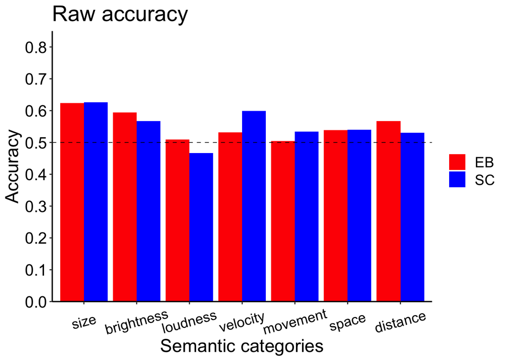

```r
categoryAccuracy_tidy <- allData %>%
  group_by(group, category) %>%
  summarize(rawAccuracy = mean(rawAccuracy), nativeAccuracy = mean(nativeAccuracy),
            .groups = 'keep')

ggplot(data = categoryAccuracy_tidy,
       aes(x = as.factor(category), y = rawAccuracy, fill = group)) +
  geom_bar(stat="identity", position=position_dodge()) +
  theme_classic() +
  scale_fill_manual(values=c('red','blue'), labels=c('EB', 'SC')) +
  scale_y_continuous(limits=c(0, 0.85), breaks=seq(0, 0.85, 0.1), expand = c(0,0)) +
  scale_x_discrete(limits=c("1", "3", "4", "6", "7", "8", "9"),
                   labels = c("size", "brightness", "loudness", "velocity", "movement", "space", "distance")) +
  labs(x="Semantic categories", y="Accuracy") +
  ggtitle("Raw accuracy") +
  theme(
    text=element_text(size=18),
    axis.line = element_line(size = 0.6),
    axis.text.x = element_text(size=14,colour="black",
                               angle = 15,
                               vjust = .5,
                               hjust = 0.5),
    axis.text.y = element_text(size=16, colour='black'),
    legend.title=element_blank())+
  geom_hline(yintercept=c(0.5), linetype="dashed", colour="black", size=0.3)
```

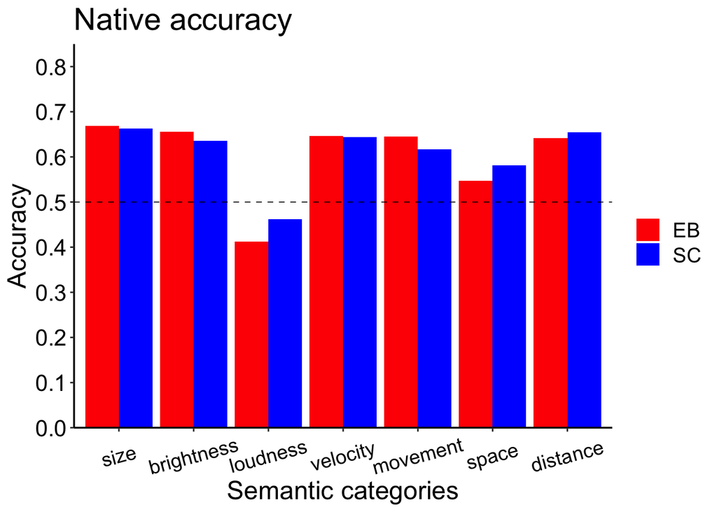

```r
ggplot(data = categoryAccuracy_tidy,
       aes(x = as.factor(category), y = nativeAccuracy, fill = group)) +
  geom_bar(stat="identity", position=position_dodge()) +
  theme_classic() +
  scale_fill_manual(values=c('red','blue'), labels=c('EB', 'SC')) +
  scale_y_continuous(limits=c(0, 0.85), breaks=seq(0, 0.85, 0.1), expand = c(0,0)) +
  scale_x_discrete(limits=c("1", "3", "4", "6", "7", "8", "9"),
                   labels = c("size", "brightness", "loudness", "velocity", "movement", "space", "distance")) +
  labs(x="Semantic categories", y="Accuracy") +
  ggtitle("Native accuracy") +
  theme(
    text=element_text(size=18),
    axis.line = element_line(size = 0.6),
    axis.text.x = element_text(size=14,colour="black",
                               angle = 15,
                               vjust = .5,
                               hjust = 0.5),
    axis.text.y = element_text(size=16, colour='black'),
    legend.title=element_blank())+
  geom_hline(yintercept=c(0.5), linetype="dashed", colour="black", size=0.3)
```